# A3: Incarceration

### Introduction

In assignment 3, I will be discovering the patterns and changes of different genders in terms of the jail rates. Learning thees patterns can help us know the social stability changes in the United States overtime. We can also has a better understanding of the gender discrimination of the Justice system across country. The variables that I chose are the `male_pop_jail_rate`, `female_pop_jail_rate`, `total_jail_pop_rate`, `state`, and `county_name`. The `male_pop_jail_rate` is the jail rate of the male population. `female_pop_jail_rate` is the jail rate for the female population. The `total_jail_pop_rate` is the total population. I can use the variables above to calculate the mean, max, minimum value.

### Summary Information

From my findings, I found that the total jail rate of 2018 is 610.72667, which is almost 3 times the total jail rate of the year 1990 (220.2448591). I also found that the jail rate of males in prison greatly differ from the jail rate of females in the United States. The mean jail rate of male in the most recent date in 2018 is 985.1914734, compared to the jail rate of female, which is 157.6517019. Lastly, I found out that the state of the most jail population rate has always been Texas. In 1990, the region that has the most jail rate is Reeves County, TX; In 2018, the region that has the most jail rate is King County, TX.

### The Dataset

The data was collected by Vera Institute of Justice. The data from the BJS Census of Jails, Annual Survey of Jails and DRCP. Vera Institute of Justice created this dataset for the public interest in order to help understand, explain, and disrupt the criminal legal and immigration systems and their devastating impacts. Vera institute want to find the county-level variability in incarceration rates in the United States. There are 91031 observations in this data, with 23 unique features. When we are manipulating the data set, we should make our conclusion based on several tests rather than a single graph or a correlation test. A limitation of the data set is the number of N/A values there are present in the data, it is probably because of the date. Back to 1990s, it is somewhat hard for people to keep track of the jail and prison data and there’s also a possibility that the data from that time is imprecise and even wrong. I think the ethical concerns of the dataset is the way they collected the data, we should be careful with writing conclusions regarding the gender and race, we should provide explanations with the consideration of the data set’s definition of gender and race.

### Trends Over Time Chart

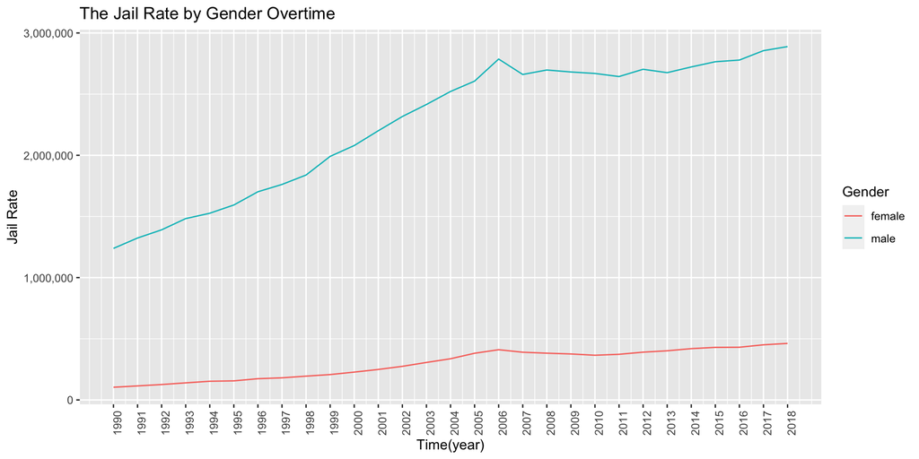

The first chart depicts the trends of jail rate of male and female overtime(1990-2018). The purpose of the chart is to show the trends of the jail rate in terms of different genders. Through the tends we can clear see the changes and the amount disparities between male and female in jail rates across country. Putting two gender’s trend in one graph can allow us to understand the potential relationship between the jail rates of two genders. Besides, we may also derive and associate possible national events that might influenced the rates of incarceration for different genders.

Through the trend we can see that the increase rate for both gender is quite high before the year 2006; after 2006, both of the gender’s jail rate decrease for about 5 years, and the jail rate started to rise again after the year 2011. In general, the change of male jail rate is quiet dramatic compared to the female jail rate.

### Variable Comparison Chart

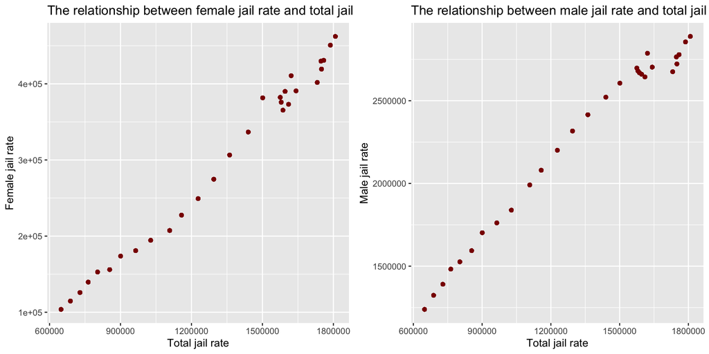

The second chart depicts the relationship between the total jail rate and female’s/male’s jail rate.

The side-by-side scatter plot allow us to identify the difference more clearly and to make conclusions about any increase/decrease in a gender in jail would just simply be due to an overall increase in that gender in the total population.

Through the chart we can notice that as the total number of the jail population grow, the jail rate of male increases much more dramatic than the jail rate of female. In general, all of the variables are positively correlated.

### Map

This map portrays the jail rate of male in the United States in 2018 by state.

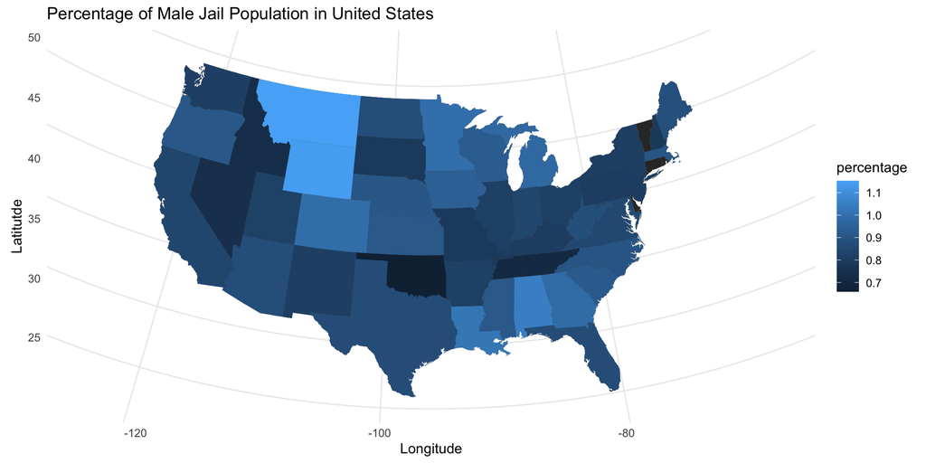